# Classification Using a Logistic Regression Model

In this notebook our goal is to be able to classify a neuroblastoma patient as having high risk (HR) or low risk (LR) neuroblastoma disease, based on the gene expression pattern of the tumor isolated from the patient using a Machine Learning algorithm.

Plots were first based on a DataCamp tutorial [@Chugh2023]. Other tutorials used were [@JerryAn2020] and [@Lu].

## Preparation

### Load libraries

```r
library(readr)
library(tidymodels)
library(stringr)
library(shiny)
library(dplyr)
```

### Process data

Load dataframe

```r
kocak_df <- read.csv("../data/r2_gse62564_GSVA_inss_mycn_status_selected.csv")
```

Remove problematic columns

```r
kocak_df <- kocak_df %>% dplyr::select(-c(sample.id))
```

Make Factors

```r
kocak_df$high_risk   <- as.factor(kocak_df$high_risk)
kocak_df$inss_stage  <- as.factor(kocak_df$inss_stage)
kocak_df$mycn_status <- as.factor(kocak_df$mycn_status)
```

Make numeric

```r
kocak_df$MYCN <- as.numeric(kocak_df$MYCN)
```

Change variable name

```r
kocak_df_clinical_maintained_df <- kocak_df
```

Remove inss_stage and mycn_status information to avoid influencing the model fitting

```r
kocak_df <- kocak_df %>% dplyr::select(-c(inss_stage, mycn_status))
```

## Look at some data

### Split data

Split data into train set and test set

```r
set.seed(421)
split <- initial_split(kocak_df, prop = 0.8, strata = high_risk)
train <- split %>%
  training()
test <- split %>%
  testing()
```

### Fitting and Evaluating the Model

Train a logistic regression model

```r
model <- logistic_reg(mixture = double(1), penalty = double(1)) %>%
  set_engine("glmnet") %>%
  set_mode("classification") %>%
  fit(high_risk ~ ., data = train)
```

Model summary

```r
tidy(model)
```

```
## # A tibble: 23 × 3
##    term                           estimate penalty
##    <chr>                             <dbl>   <dbl>
##  1 (Intercept)                    -0.763         0
##  2 MYCN                            0.00223       0
##  3 STC1                            0.0181        0
##  4 P4HA1                           0.0138        0
##  5 BHLHE40                        -0.00111       0
##  6 HIF1A                          -0.00289       0
##  7 ELVIDGE_HIF1A_TARGETS_UP        1.43          0
##  8 Quiescence.Down.Cheung          0.459         0
##  9 T.cell.exhaustion               0.292         0
## 10 HALLMARK_INFLAMMATORY_RESPONSE -0.971         0
## # ℹ 13 more rows
```

### Making predictions

Class Predictions

```r
pred_class <- predict(model,
                      new_data = test,
                      type = "class")

pred_class
```

```
## # A tibble: 101 × 1
##    .pred_class
##    <fct>
##  1 yes
##  2 yes
##  3 no
##  4 no
##  5 no
##  6 no
##  7 no
##  8 no
##  9 no
## 10 no
## # ℹ 91 more rows
```

Class Probabilities

```r
pred_proba <- predict(model,
                      new_data = test,
                      type = "prob")
pred_proba
```

```
## # A tibble: 101 × 2
##    .pred_no .pred_yes
##       <dbl>     <dbl>
##  1   0.0962    0.904
##  2   0.0415    0.958
##  3   0.929     0.0710
##  4   0.902     0.0976
##  5   0.989     0.0107
##  6   0.931     0.0690
##  7   0.930     0.0701
##  8   0.934     0.0656
##  9   0.943     0.0568
## 10   0.952     0.0482
## # ℹ 91 more rows
```

Evaluate the model using the accuracy() function

```r
results <- test %>%
  dplyr::select(high_risk) %>%
  bind_cols(pred_class, pred_proba)
```

Print the results to see the predicted labels and the actual labels

```r
results
```

```
##     high_risk .pred_class     .pred_no   .pred_yes
## 1         yes         yes 0.0962015640 0.903798436
## 2         yes         yes 0.0415423791 0.958457621
## 3          no          no 0.9289635193 0.071036481
## 4          no          no 0.9023574563 0.097642544
## 5          no          no 0.9893081953 0.010691805
## 6          no          no 0.9310281595 0.068971840
## 7          no          no 0.9298698703 0.070130130
## 8          no          no 0.9344081675 0.065591833
## 9          no          no 0.9432419442 0.056758056
## 10         no          no 0.9518278641 0.048172136
## 11         no          no 0.9286234946 0.071376505
## 12         no          no 0.9293676030 0.070632397
## 13         no          no 0.9813997676 0.018600232
## 14         no          no 0.9645281518 0.035471848
```

[output cut: 87 more lines]

Calculate the accuracy of the model using the accuracy function

```r
accuracy(results, truth = high_risk, estimate = .pred_class)
```

```
## # A tibble: 1 × 3
##   .metric  .estimator .estimate
##   <chr>    <chr>          <dbl>
## 1 accuracy binary         0.911
```

## User’s input

In the initial stages of development of this application, the robot only took these values, i.e.: the user could not change these values. For my convenience, the oneSampleObject is used in this part so I can easily copy the values to demonstrate the usefulness of the tab in the rendered Shiny app, once the app is rendered.

```r
oneSampleData <- c(100000000,2,3,4,5,6,7,8,9,10,11,12,13,14,15,16,17,18,19,20,21,22, "unknown")
```

Print the oneSampleData object

```r
oneSampleData
```

```
##  [1] "1e+08"   "2"       "3"       "4"       "5"       "6"       "7"
##  [8] "8"       "9"       "10"      "11"      "12"      "13"      "14"
## [15] "15"      "16"      "17"      "18"      "19"      "20"      "21"
## [22] "22"      "unknown"
```

I later realized that the user input taken is not parsed the same way the oneSampleData line above. Then we create the oneSampleData object which is entered by the user. The oneSampleData object is a sequence of numbers that corresponds to the phenotypes that we found, drive neuroblastoma aggressiveness.

```r
oneSampleData <- readline(prompt = "Enter any number (1): ")
```

```
## Enter any number (1):
```

The idea here is that if we can quantify these numbers in a patient say for example by quantifying this patient’s gene expression, we can classify the neuroblastoma risk group that the patient belongs to.

## Shiny Application

Here the Shiny application will be divided into 3 parts: 1) the user interface (UI); 2) the server; 3) the calling of the Shiny app.

### User Interface (UI)

We define bellow, the pieces of the data that users can manipulate. To start, it maybe a good idea to look at where the “Risk Classifier Machine” title will locate in the rendered application.

```r
ui <- fluidPage(
  ## The line below is the application title. Check where is the title in the rendered application.
  titlePanel("Risk Clissifier Machine"),
  sidebarLayout(
    sidebarPanel(
      ## The line below is the clinical variable that is manipulated in the server.
      selectInput("ClinicalVariable",
                  ## The line bellow is the clinical variable as read and seen by the user.
                  ## Notice the difference between High Risk and high_risk
                  "Clinical Variable:", c("High Risk"  = "high_risk",
                                          "INSS Stage" = "inss_stage",
                                          "MYCN Status" = "mycn_status")),
      checkboxInput("outliers", "Show outliers", TRUE),
      ## The user can choose some of the predictor features to visualize.
      ## Visualization: predictor features in y axis and clinical variable in the x axis.
      selectInput("PredictorFeatures",
                  "Predictor Features:", c("mycn"  = "MYCN",
                                           "stc1" = "STC1",
                                           "hif1a" = "HIF1A",
                                           "p4ha1" = "P4HA1",
                                           "inflammation" = "HALLMARK_INFLAMMATORY_RESPONSE",
                                           "hypoxia" = "HALLMARK_HYPOXIA")),

      ## This seems to be the only way to take the user input as a vector
      ## UserInputFeatureValues seems to be a variable associated with oneSampleData
      textInput("UserInputFeatureValues", "Values for Patient Features: ", oneSampleData)

    ),

    mainPanel(
      # This part generates the clinical variable boxplot.
      # The user can choose between high risk, inss stage and MYCN status.
      h3(textOutput("caption")),
      plotOutput("ClinVarPlot"),
      # verbatimTextOutput("UserValuesStored"),

      ## The line bellow indicates where  values inputed by the user will appear in the rendered application.
      h4('Results of User Interaction'),
      verbatimTextOutput("UserValuesStored"),
      h5('Object UserInputFeatureValues'),
      verbatimTextOutput("oid1"),
      h5('Object pred_class_one_sample'),
      verbatimTextOutput("oid3"),
    )
  )
)
```

### Server

In this part we generate the processes that are done on the inputs of the user. Here we will for example, determine how the oneSampleObject, informed by the user, is processed by the Machine Learning model to generate the high risk classification of the patient, for us.

```r
server <- function(input, output) {

  formulaText <- reactive({
    paste(input$PredictorFeatures," ~", input$ClinicalVariable)
  })

  # render the clinical variable chosen by the user as text
  output$caption <- renderText({
    formulaText()
  })

  # render the user input for the robot classification as text
  # output$UserValuesStored <- renderText({input$UserInputFeatureValues})
  output$UserValuesStored <- renderText({input$oneSampleData})


  output$oid1 <- renderPrint({
    cat("As string:\n")
    cat(input$UserInputFeatureValues)
  }
  )


  output$oid3 <- renderPrint({
    cat("As string:\n")
    cat(input$UserInputFeatureValues)

    ###### 3. Split data
    # Split data into train set and test set
    set.seed(421)
    split <- initial_split(kocak_df, prop = 0.8, strata = high_risk)
    train <- split %>%
      training()
    test <- split %>%
      testing()

    ###### 4. Fitting and Evaluating the Model
    # Train a logistic regression model
    model <- logistic_reg(mixture = double(1), penalty = double(1)) %>%
      set_engine("glmnet") %>%
      set_mode("classification") %>%
      fit(high_risk ~ ., data = train)

    # Model summary
    tidy(model)



    ###### 5. Making predictions

    # Class Predictions
    pred_class <- predict(model,
                          new_data = test,
                          type = "class")

    # Class Probabilities
    pred_proba <- predict(model,
                          new_data = test,
                          type = "prob")

    # Evaluate the model using the accuracy() function
    results <- test %>%
      dplyr::select(high_risk) %>%
      bind_cols(pred_class, pred_proba)

    accuracy(results, truth = high_risk, estimate = .pred_class)

    ###### The step in which the user input is transformed has to go inside the output in the server
    ###### 6. Prediction for 1 sample w/ TRANSFORMATION OF USER INPUT

    ##### 6.2. Process User's input
    # It is required to split the input
    oneSampleData <- str_split(input$UserInputFeatureValues, ",", n = 23)
    # Check if oneSampleData is being parsed
    print(oneSampleData)
    # Fix the user input for MYCN gene expression
    oneSampleData[[1]][1] <- substr(oneSampleData[[1]][1], start = 3, stop = nchar(oneSampleData[[1]][1]))
    # Fix the label for unknown sample
    oneSampleData[[1]][23] <- "unknown"

    # Make the user input, the first element in the list
    oneSampleData <- oneSampleData[[1]]

    names(oneSampleData) = c("MYCN","STC1","P4HA1","BHLHE40",
                             "HIF1A","ELVIDGE_HIF1A_TARGETS_UP","Quiescence.Down.Cheung",
                             "T.cell.exhaustion","HALLMARK_INFLAMMATORY_RESPONSE","HALLMARK_HYPOXIA","ST8SIA1",
                             "Quiescence.Up.Cheung", "HALLMARK_TNFA_SIGNALING_VIA_NFKB","HALLMARK_MITOTIC_SPINDLE",
                             "HALLMARK_DNA_REPAIR", "HALLMARK_G2M_CHECKPOINT", "HALLMARK_APOPTOSIS", "HALLMARK_E2F_TARGETS",
                             "HALLMARK_GLYCOLYSIS","HALLMARK_P53_PATHWAY","CHIP_HIF1A_300", "CHIP_EPAS1_300","high_risk")

    oneSampleData_df = data.frame(as.list(oneSampleData))

    oneSampleData_df$high_risk <- as.factor(oneSampleData_df$high_risk)

    # Make all character columns, numeric
    oneSampleData_df <- oneSampleData_df %>% mutate_if(is.character,as.numeric)

    # Class Predictions
    pred_class_one_sample <- predict(model,
                                     new_data = oneSampleData_df,
                                     type = "class")
    # Class Probabilities
    pred_proba_one_sample <- predict(model,
                                     new_data = oneSampleData_df,
                                     type = "prob")


    paste0("Risk Group Prediction Calculated by the Robot is (1 = Low Risk; 2 = High Risk): ", pred_class_one_sample)

   #paste0("1 = Low Risk; 2 = High Risk")
  }
  )

  # Render the clinical variable chosen by the user as plot.
  output$ClinVarPlot <- renderPlot({
    boxplot(as.formula(formulaText()),
            data=kocak_df_clinical_maintained_df,
            outline=input$outliers,
            col="#007bc2",pch=19)
  })
}
```

## Call Shiny App

```r
shinyApp(ui, server)
```

```
## PhantomJS not found. You can install it with webshot::install_phantomjs(). If it is installed, please make sure the phantomjs executable can be found via the PATH variable.
```

```
##
## Listening on http://127.0.0.1:7365
```

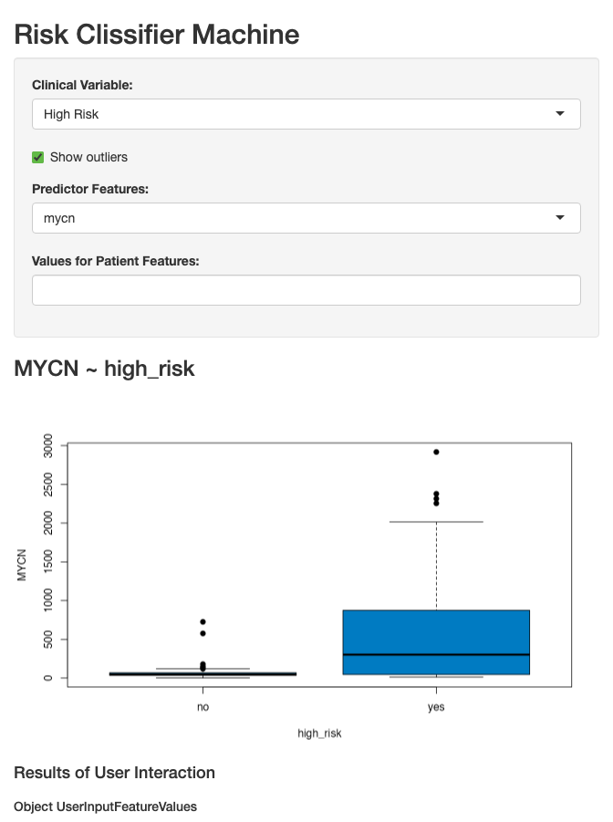

### Redefine the User Interface (UI)

In this part, in the main panel, I am removing the plot h3, around line 101, above

```r
ui <- fluidPage(
  titlePanel("Risk Clissifier Machine"),
  sidebarLayout(
    sidebarPanel(

      selectInput("ClinicalVariable", "Clinical Variable:", c("High Risk"  = "high_risk","INSS Stage" = "inss_stage","MYCN Status" = "mycn_status")),
      checkboxInput("outliers", "Show outliers", TRUE),
      selectInput("PredictorFeatures", "Predictor Features:", c("mycn"  = "MYCN",
                                                                "stc1" = "STC1",
                                                                "hif1a" = "HIF1A",
                                                                "p4ha1" = "P4HA1",
                                                                "inflammation" = "HALLMARK_INFLAMMATORY_RESPONSE",
                                                                "hypoxia" = "HALLMARK_HYPOXIA")),

      ## This seems to be the only way to take the user input as a vector
      textInput("UserInputFeatureValues", "Values for Patient Features: ", oneSampleData)

    ),

    mainPanel(
      h4('Results of User Interaction'),
      verbatimTextOutput("UserValuesStored"),
      h5('Object UserInputFeatureValues'),
      verbatimTextOutput("oid1"),
      h5('Object pred_class_one_sample'),
      verbatimTextOutput("oid3"),
    )
  )
)
```

### Re-Call Shiny App

```r
shinyApp(ui, server)
```

```
##
## Listening on http://127.0.0.1:7365
```

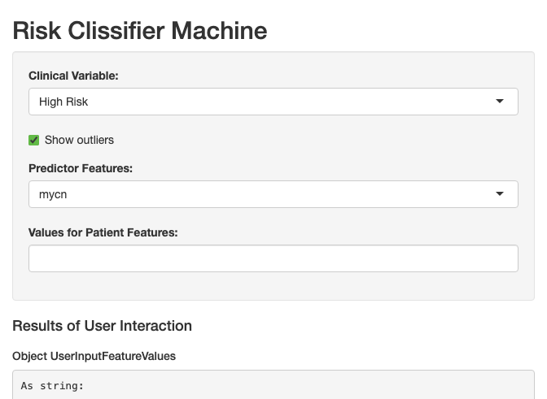

## Reference websites

```r
# References:

#   https://stringr.tidyverse.org/reference/str_split.html
# Extract first value from list:
#   https://stackoverflow.com/questions/20950221/extracting-first-value-from-a-list
# Extract 2 characters from string:
#   https://stackoverflow.com/questions/38750535/extract-the-first-2-characters-in-a-string
# Retain last character in string:
#   https://stackoverflow.com/questions/23184198/retain-last-character-in-string-with-r
```